# Lab 3

Anders Lie

```r
library(tidyverse)
dat <- readxl::read_xls('GSS.xls')
```

# Data Cleaning

```r
# Change names
dat <- dat %>%
  rename(
    survey_year=`Gss year for this respondent`,
    god=`Rs confidence in the existence of god`,
    happiness=`General happiness`,
    lib_or_consv = `Think of self as liberal or conservative`,
    polparty = `Political party affiliation`,
    fam_income = `Total family income`,
    race = `Race of respondent`,
    sex = `Respondents sex`,
    years_edu = `Highest year of school completed`,
    age = `Age of respondent`,
    marital_status = `Marital status`,
    weekly_hrs_worked = `Number of hours usually work a week`,
    id = `Respondent id number`,
    ballot = `Ballot used for interview`
  )

# Reformat years of education and age to numeric
dat <- dat %>%
  mutate(
    years_edu=as.numeric(years_edu),
    age=as.numeric(age)
  )
```

# 1

```r
dat %>%
  group_by(marital_status) %>%
  summarize(avg_edu_years=mean(years_edu, na.rm=TRUE)) %>%
  arrange(desc(avg_edu_years)) %>%
  rename(`Marital Status`=marital_status, `Average Number of Years of Education`=avg_edu_years)
```

| Marital Status | Average Number of Years of Education |
| --- | --- |
| No answer | 15.47826 |
| Never married | 13.38954 |
| Divorced | 13.10582 |
| Married | 12.96828 |
| Separated | 11.85580 |
| Widowed | 11.19825 |
| NA | NaN |

We can see that people who did not answer about their marital status have significantly higher education on average, for some reason. Also, those who were widowed or separated have less education on average than those who were never married, divorced, or are married.

# 2

```r
better_educated <- dat %>%
  group_by(marital_status) %>%
  mutate(avg_edu_years=mean(years_edu, na.rm=TRUE)) %>%
  filter(years_edu > avg_edu_years) %>%
  select(-avg_edu_years) %>%
  ungroup

str(better_educated)
```

```
## tibble [30,714 x 14] (S3: tbl_df/tbl/data.frame)
##  $ survey_year      : num [1:30714] 1972 1972 1972 1972 1972 ...
##  $ god              : chr [1:30714] "Not applicable" "Not applicable" "Not applicable" "Not applicable" ...
##  $ happiness        : chr [1:30714] "Not too happy" "Not too happy" "Pretty happy" "Not too happy" ...
##  $ lib_or_consv     : chr [1:30714] "Not applicable" "Not applicable" "Not applicable" "Not applicable" ...
##  $ polparty         : chr [1:30714] "Ind,near dem" "Not str democrat" "Ind,near dem" "Ind,near dem" ...
##  $ fam_income       : chr [1:30714] "Not applicable" "Not applicable" "Not applicable" "Not applicable" ...
##  $ race             : chr [1:30714] "White" "White" "White" "White" ...
##  $ sex              : chr [1:30714] "Female" "Female" "Male" "Male" ...
##  $ years_edu        : num [1:30714] 16 17 14 16 13 14 14 17 14 13 ...
##  $ age              : num [1:30714] 23 27 26 27 30 54 24 46 21 21 ...
##  $ marital_status   : chr [1:30714] "Never married" "Married" "Never married" "Never married" ...
##  $ weekly_hrs_worked: chr [1:30714] "Not applicable" "Not applicable" "Not applicable" "Not applicable" ...
##  $ id               : num [1:30714] 1 4 6 8 11 16 17 19 20 23 ...
##  $ ballot           : chr [1:30714] "Not applicable" "Not applicable" "Not applicable" "Not applicable" ...
```

# 3

```r
dat <- dat %>%
  mutate(hap_val=
          ifelse(happiness == 'Very happy', 2,
          ifelse(happiness == 'Pretty happy', 1,
          ifelse(happiness == 'Not too happy', 0, NA
          )))
        )

dat %>%
  group_by(marital_status) %>%
  summarize(avg_happiness_val=mean(hap_val, na.rm=TRUE)) %>%
  arrange(desc(avg_happiness_val)) %>%
  rename(`Marital Status`=marital_status, `Average Happiness (0-2)`=avg_happiness_val)
```

| Marital Status | Average Happiness (0-2) |
| --- | --- |
| Married | 1.327888 |
| No answer | 1.100000 |
| Never married | 1.053136 |
| Widowed | 1.044712 |
| Divorced | 1.006160 |
| Separated | 0.880000 |
| NA | NaN |

If we define happiness on a scale from 0 (Not too happy) to 2 (Very happy) then we can group by marital status and see that on average, people who are married are happiest, while people who are separated are the least happy.

```r
dat <- dat %>%
  mutate(hap_bool=
          ifelse(hap_val >= 1, TRUE,
          ifelse(hap_val == 0, FALSE, NA
          ))
        )
```

We can also group people’s happiness into TRUE (i.e. they are happy) if they say they are “Very happy” or “Pretty happy”, and FALSE (i.e. not happy) if they say they are “Not too happy”. In this case, we can explore the categorizations of happiness by marital status like so:

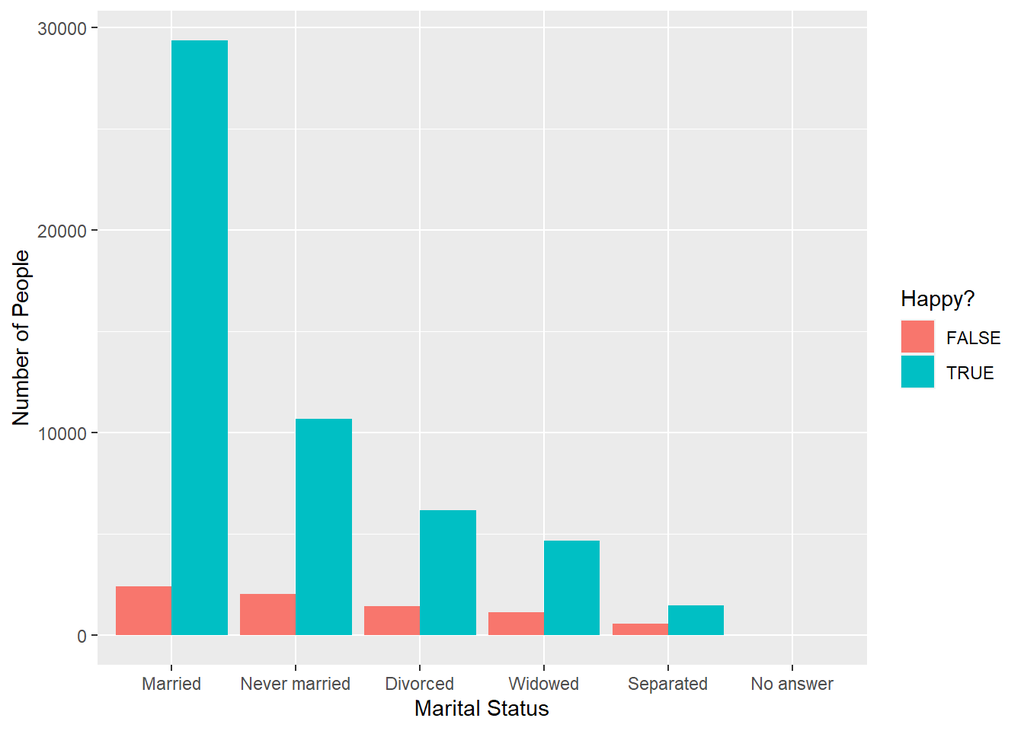

```r
dat1 <- dat %>% filter(!is.na(hap_bool))
dat1$marital_status <- fct_infreq(dat1$marital_status)
ggplot(dat1, aes(x=marital_status, fill=hap_bool)) + geom_bar(position='dodge') +
  xlab('Marital Status') + ylab('Number of People') + labs(fill="Happy?")
```

We can see that a lot of people who took the survey were married or never married, and that there are a lot of happy married people. Also, the proportion of happy to unhappy people seems to be higher for those who were married or never married as opposed to those who were divorced, widowed, or separated.

# 4

```r
dat %>%
  group_by(polparty) %>%
  summarize(avg_happiness_val=mean(hap_val, na.rm=TRUE)) %>%
  arrange(desc(avg_happiness_val)) %>%
  rename(`Political Party Affiliation`=polparty, `Average Happiness (0-2)`=avg_happiness_val)
```

| Political Party Affiliation | Average Happiness (0-2) |
| --- | --- |
| Strong republican | 1.331300 |
| Not str republican | 1.265084 |
| Ind,near rep | 1.215683 |
| Don't know | 1.181818 |
| No answer | 1.168116 |
| Strong democrat | 1.159429 |
| Not str democrat | 1.153046 |
| Independent | 1.129264 |
| Other party | 1.124254 |
| Ind,near dem | 1.117615 |

[output cut: 1 more lines]

Viewing the average happiness value again, except grouping by political party, we can see that in general, people affiliated with the republican party are happiest, while those who are independent near democratic, affiliated with some other party, or independent, are the least happy.

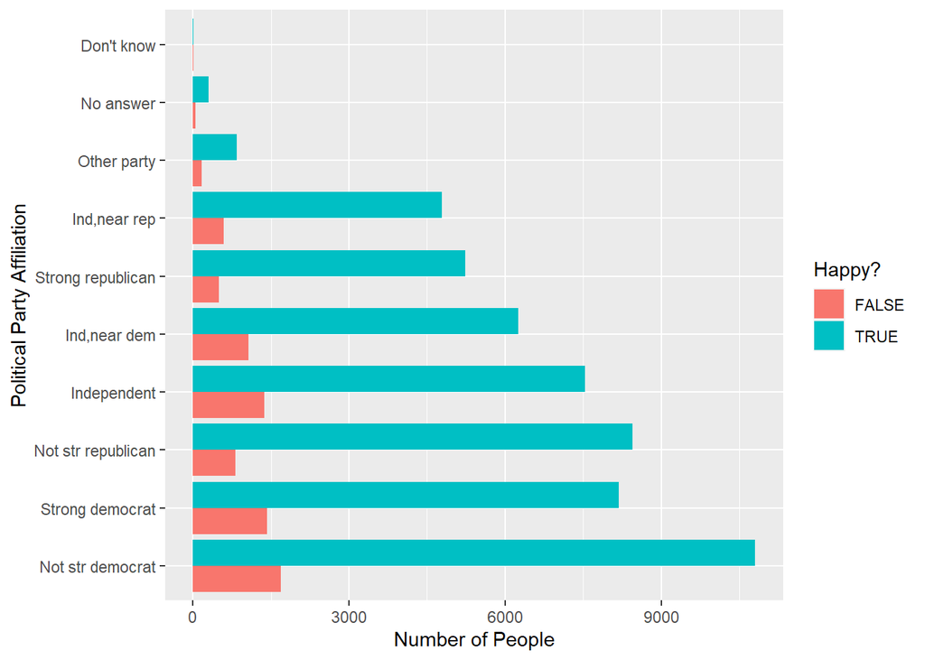

```r
dat1 <- dat %>% filter(!is.na(hap_bool))
dat1$polparty <- fct_infreq(dat1$polparty)
ggplot(dat1, aes(x=polparty, fill=hap_bool)) + geom_bar(position='dodge') +
  xlab('Political Party Affiliation') + ylab('Number of People') + labs(fill="Happy?") +
  coord_flip()
```

We can see that many people who took the survey were democrats, and that many of them were happy. However, if we look at the republicans who took the survey, the ratio of happy to unhappy people is higher.

# 5

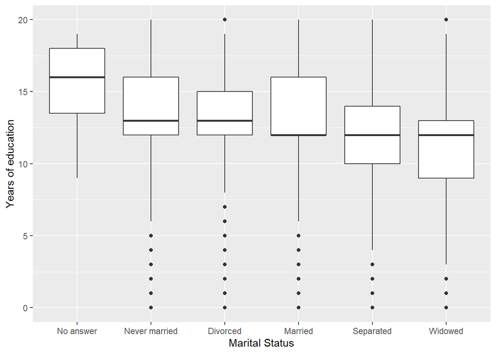

```r
dat1 <- dat %>% filter(!is.na(years_edu))
dat1$marital_status <- fct_reorder(dat1$marital_status, dat1$years_edu, .desc=TRUE, .fun=mean, na.rm=TRUE)
ggplot(dat1, aes(x=marital_status, y=years_edu)) + geom_boxplot() +
  xlab('Marital Status') + ylab('Years of education')
```

As we can see, those who did not answer about their marital status have greater education on average, followed by those who were never married, then those who are divorced, then those who are married, those who separated, and finally those who were widowed had the least years of education on average.

We can also perform a similar numerical summary:

```r
dat1 %>%
  group_by(marital_status) %>%
  summarize(avg_edu_years=mean(years_edu, na.rm=TRUE)) %>%
  arrange(desc(avg_edu_years)) %>%
  rename(`Marital Status`=marital_status, `Average Number of Years of Education`=avg_edu_years)
```

| Marital Status | Average Number of Years of Education |
| --- | --- |
| No answer | 15.47826 |
| Never married | 13.38954 |
| Divorced | 13.10582 |
| Married | 12.96828 |
| Separated | 11.85580 |
| Widowed | 11.19825 |

This gives us the exactly average number of years of education for each marital status.

It’s difficult to attribute possible reasons for these correlations. However, perhaps it makes sense that those who were never married have more years of education that those who are married, since those who are unmarried only have their own disposable income, but a higher education can make that income greater. Those who were widowed might have lower education on average because they are more likely to be in poor conditions mentally or financially which could detract from their ability or willingness to go to school.

# 6

## i.

First, we explore the relationship between total family income and happiness.

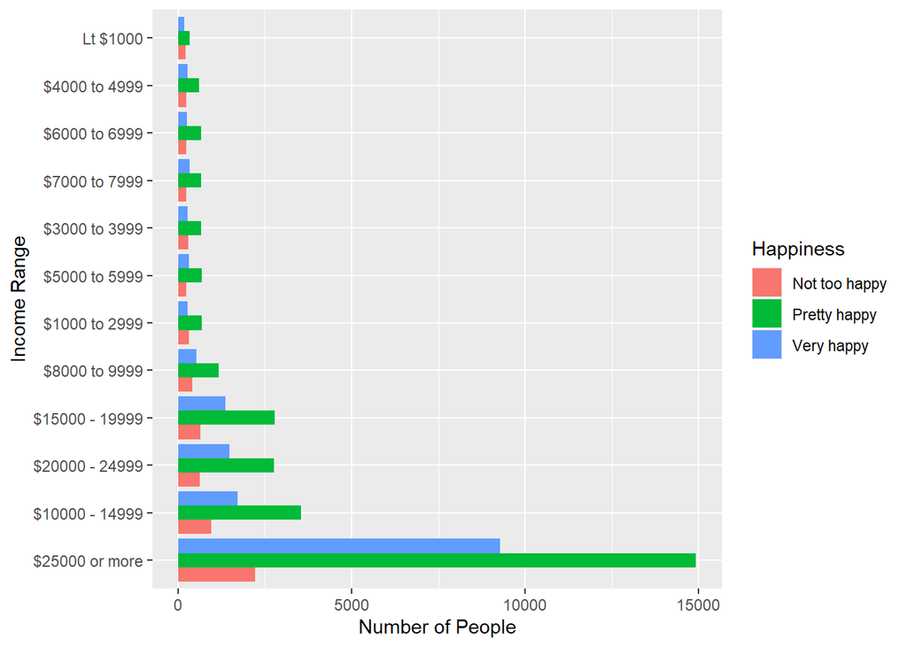

```r
dat1 <- dat %>% filter(!is.na(hap_val) & !is.na(fam_income))
dat1 <- dat1 %>% filter(fam_income != 'No answer' & fam_income != "Don't know" & fam_income != 'Refused' & fam_income != 'Not applicable')
dat1$fam_income <- fct_infreq(dat1$fam_income)
ggplot(dat1, aes(x=fam_income, fill=happiness)) + geom_bar(position='dodge') +
  xlab('Income Range') + ylab('Number of People') + labs(fill="Happiness") + coord_flip()
```

This gives us a good idea of how many people from each income range where not happy, pretty happy, or not too happy. We can see that a lot of people who surveyed had >= $25000 income, and that most of them were happy. On the other hand, people making less than $1000 were significantly less happy. We can see exactly how happy these income ranges were on average with a numerical summary:

```r
dat1 %>%
  group_by(fam_income) %>%
  summarize(avg_hap_val=mean(hap_val, na.rm=TRUE)) %>%
  arrange(desc(avg_hap_val)) %>%
  rename(`Income Range`=fam_income, `Average Hapiness (0-2)`=avg_hap_val)
```

| Income Range | Average Hapiness (0-2) |
| --- | --- |
| $25000 or more | 1.2677139 |
| $20000 - 24999 | 1.1743758 |
| $15000 - 19999 | 1.1526062 |
| $10000 - 14999 | 1.1229878 |
| $7000 to 7999 | 1.0740439 |
| $5000 to 5999 | 1.0670978 |
| $8000 to 9999 | 1.0581506 |
| $4000 to 4999 | 1.0319432 |
| $6000 to 6999 | 1.0234375 |
| $3000 to 3999 | 0.9861901 |

[output cut: 2 more lines]

For the most part, this summary makes sense. Generally, higher income means higher average happiness. However, there are some ranges that are in an order one might not expect. For example, the $7000 to 7999 and $5000 to 5999 ranges are happier on average than the $8000 to 9999 range, and the $4000 to 6999 range is happier than the $6000 to 6999 range. However, there are not a lot of people surveyed at these ranges, so this variation could just be due to the people selected.

# ii.

Next, we explore the relationship between the amount of weekly hours worked on average and happiness.

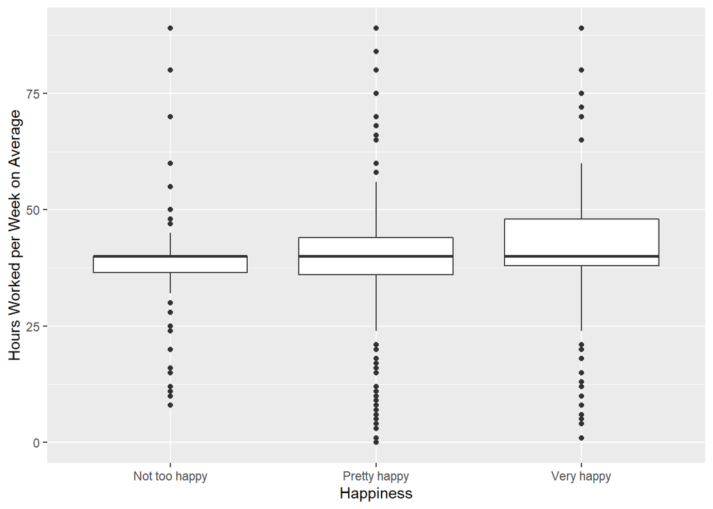

```r
# Clean up weekly hours worked
dat1 <- dat1 %>% filter(!is.na(weekly_hrs_worked) & weekly_hrs_worked != 'Not applicable' & weekly_hrs_worked != "Don't know" & weekly_hrs_worked != 'No answer')
dat1$weekly_hrs_worked <- as.numeric(dat1$weekly_hrs_worked)
dat1 %>% ggplot(aes(x=happiness, y=weekly_hrs_worked)) + geom_boxplot() + xlab('Happiness') + ylab('Hours Worked per Week on Average')
```

```r
dat1 %>%
  group_by(happiness) %>%
  summarize(avg_hrs_worked=mean(weekly_hrs_worked, na.rm=TRUE)) %>%
  arrange(desc(avg_hrs_worked)) %>%
  rename(`Happiness`=happiness, `Average Number of Hours Worked per Week`=avg_hrs_worked)
```

| Happiness | Average Number of Hours Worked per Week |
| --- | --- |
| Very happy | 40.21824 |
| Pretty happy | 39.36063 |
| Not too happy | 39.07742 |

Looking at the above numerical summary though, we can see that the average number of hours worked per week does not change very much with happiness. So although there is a general trend that more hours worked correlates with more happiness, the trend is very subtle.